# Used car prediction project

####GOAL

I have been wondered how people decide the used car prices. The purpose of this project is to improve a statistical model to predict selling price of cars. I am going to use the historical car data that have all different brands to predicting the selling prices of cars and compare the results.

####Loading and Packages This project uses past used car prices data from kaggle, which has more than 8000 records. Here are some of key variables that are helpful to be aware of for this project :

Year - year of the car when it was bought (started from 1983 to 2020)

selling_price - price that car is being sold

km_driven - Number of kilometers the car is driven

fuel - Fuel type of car (petrol / diesel / CNG / LPG / electric)

transmission - Gear transmission of the car (Automatic/Manual)

seller_type - tells if a seller is individual or dealer

Owner - Number of previous onwers of the car

####Cleaning

remove incomplete rows There are 221 incomplete rows in the dataset, and I am going to remove incomplete rows.

```r
count(vehicles)
```

```
##      n
## 1 8128
```

```r
sum(is.na(vehicles))
```

```
## [1] 221
```

```r
row_status <- complete.cases(vehicles)
vehicles <- vehicles[row_status,]
sum(is.na(vehicles))
```

```
## [1] 0
```

```r
sapply(vehicles, function(x) sum(is.na(x)))
```

```
##          name          year selling_price     km_driven          fuel
##             0             0             0             0             0
##   seller_type  transmission         owner       mileage        engine
##             0             0             0             0             0
##     max_power        torque         seats
##             0             0             0
```

####Visualization

Since I deleted all the incomplete data(NA), Now I am going to visualize the data with various variation for better understanding of dataset.

The highest number of cars is Maruti brand, followed by Hyundai, Mahindra and tata brand.

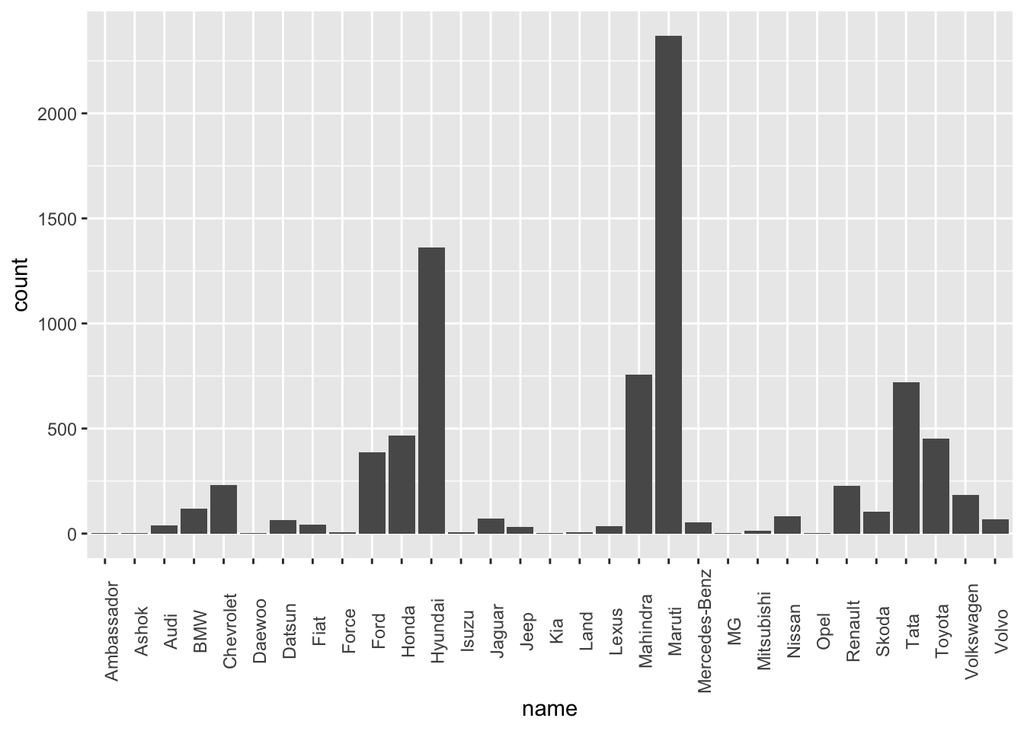

```r
vehicles$name <- word(vehicles$name,1)
ggplot(data=vehicles, aes(x=name, fil=name)) + geom_bar() + theme(axis.text.x = element_text(angle = 90))
```

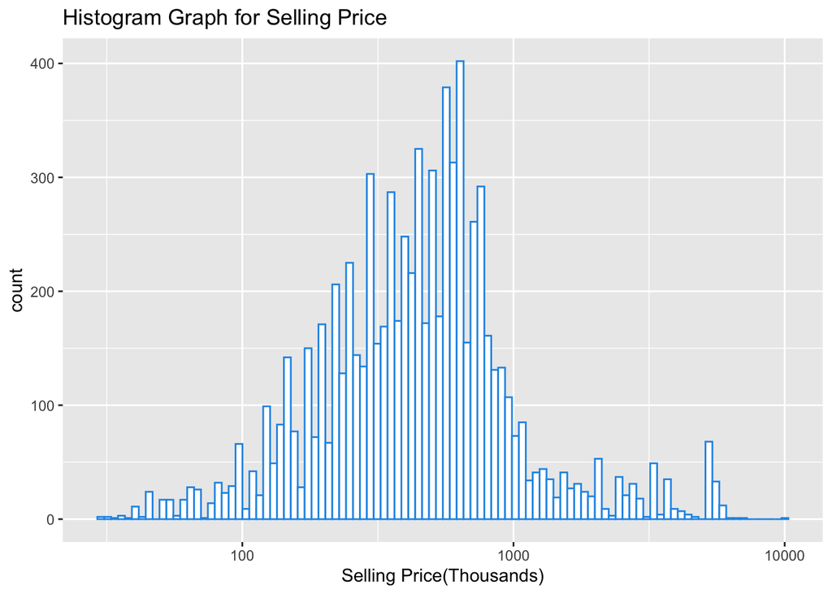

```r
ggplot(vehicles, aes(x=selling_price/1000)) +
  geom_histogram(colour=4, fill = "white", bins=100)+
  labs(x='Selling Price(Thousands)') + labs(title = "Histogram Graph for Selling Price") + scale_x_continuous(trans='log10')
```

According to this graph, we are able to check the majority of cars are sold out between the range of 1e+05 and 1e+06.

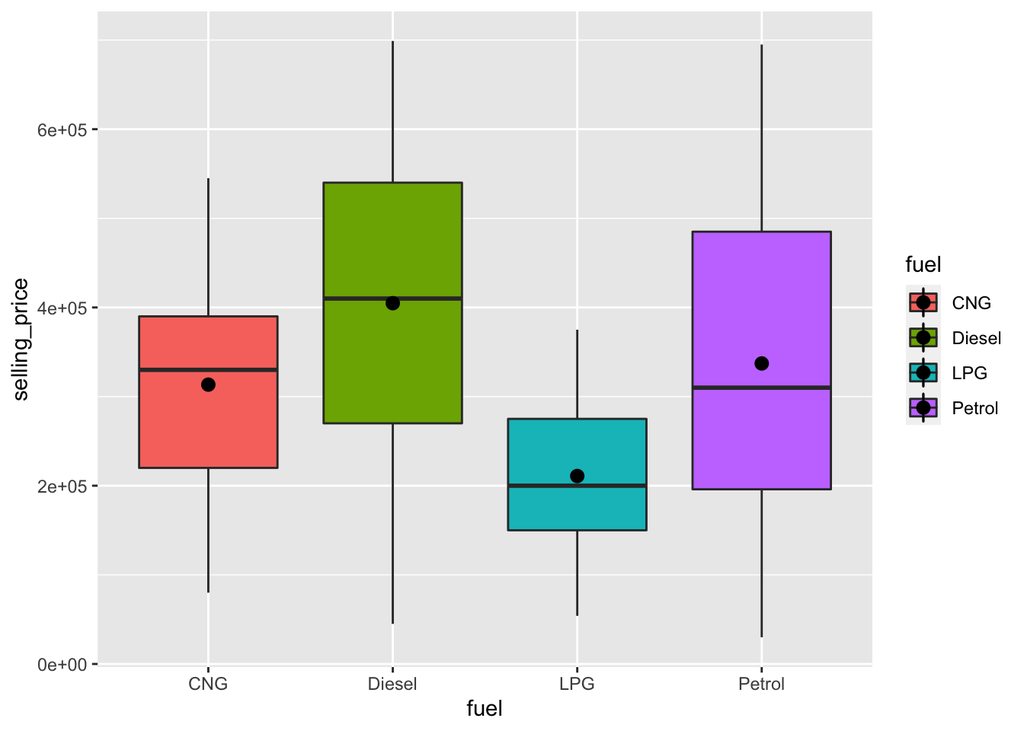

```r
vehicles %>%
filter(selling_price<700000,
       km_driven<700000) %>%
  ggplot(aes(x=fuel,y=selling_price,fill=fuel),message=FALSE,warning=FALSE)+geom_boxplot()+ stat_summary(fun="mean")
```

According to this boxplot, we can check the distribution of selling price along with fuel type. We can see selling price of LPG car is the lowest, whereas Diesel car is at higher selling price. And for Petrol type car, we can see mean value of cars are higher than the middle car value. We can see there are less number of cars that have high selling price.

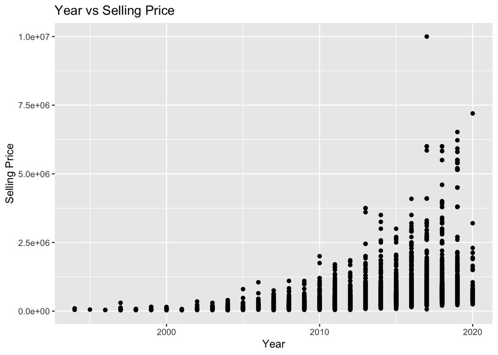

```r
vehicles %>%
  ggplot()+
    geom_point(aes(year,(selling_price))) +
    xlab("Year")+
    ylab("Selling Price")+
    ggtitle("Year vs Selling Price")
```

According to the plot we have, we can see the more recently car prices have a higher selling prices.

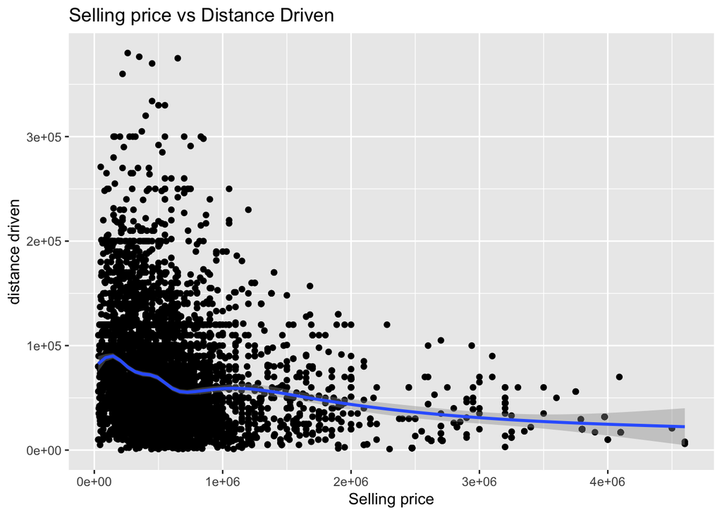

```r
vehicles %>%
  filter(selling_price <5000000, km_driven < 400000) %>%
  ggplot(aes(x=selling_price, y=km_driven),message=FALSE,warning=FALSE) + geom_point() +geom_smooth()+ labs(title="Selling price vs Distance Driven", x="Selling price", y="distance driven")
```

According to this plot, we can see when kilometer driven goes up, the selling price goes down.

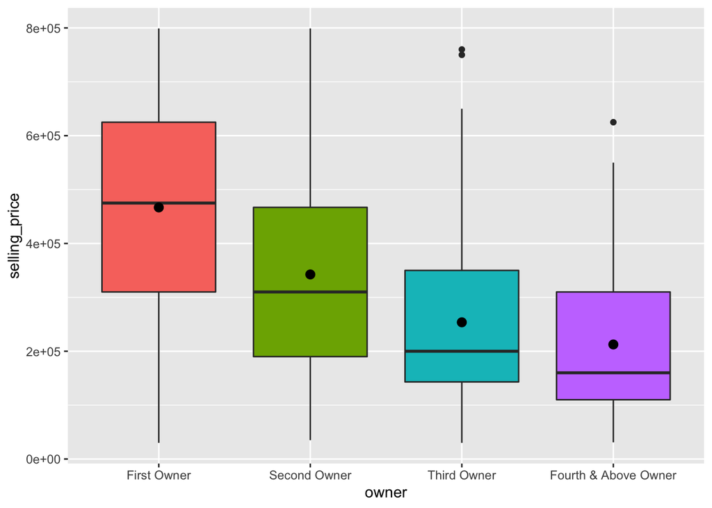

```r
vehicles$owner = factor(vehicles$owner,levels=c('First Owner','Second Owner','Third Owner','Fourth & Above Owner'))

vehicles %>%
filter(selling_price<800000,
       km_driven<100000) %>%
  ggplot(aes(x=owner,y=selling_price,fill=owner))+geom_boxplot(show.legend = FALSE)+ stat_summary(fun="mean",show.legend = FALSE)
```

According to this boxplot, we can see the prices of cars are in order of First Owner > Second Owner > Third Owner > Fourth & Above Onwer.

In order to check the correlation between all the variables, and set the mode as regression, I am going to make all the variables as numeric value and delete the useless units.

I am going to remove the each unit from mileage, engine, max_power, seats and converting them to numeric value

```r
vehicles$mileage <- str_replace(vehicles$mileage, 'kmpl', '')
vehicles$mileage <- str_replace(vehicles$mileage, 'km/kg', '')
vehicles$mileage <- as.numeric(vehicles$mileage)
```

```r
vehicles$engine <- str_replace(vehicles$engine, 'CC', '')
vehicles$engine <- as.numeric(vehicles$engine)
```

```r
vehicles$max_power <- str_replace(vehicles$max_power, 'bhp', '')
vehicles$max_power <- as.numeric(vehicles$max_power)
vehicles$max_power[is.na(vehicles$max_power)]<-mean(vehicles$max_power,na.rm=TRUE)
```

```r
vehicles$seats <- as.numeric(vehicles$seats)
```

```r
summary(vehicles)
```

```
##      name                year      selling_price        km_driven
##  Length:7907        Min.   :1994   Min.   :   29999   Min.   :      1
##  Class :character   1st Qu.:2012   1st Qu.:  270000   1st Qu.:  35000
##  Mode  :character   Median :2015   Median :  450000   Median :  60000
##                     Mean   :2014   Mean   :  649742   Mean   :  69193
##                     3rd Qu.:2017   3rd Qu.:  690000   3rd Qu.:  95750
##                     Max.   :2020   Max.   :10000000   Max.   :2360457
##      fuel           seller_type        transmission
##  Length:7907        Length:7907        Length:7907
##  Class :character   Class :character   Class :character
##  Mode  :character   Mode  :character   Mode  :character
##
##
##
##                   owner         mileage          engine       max_power
##  First Owner         :5215   Min.   : 0.00   Min.   : 624   Min.   : 32.80
##  Second Owner        :2017   1st Qu.:16.78   1st Qu.:1197   1st Qu.: 68.05
##  Third Owner         : 510   Median :19.30   Median :1248   Median : 82.00
##  Fourth & Above Owner: 160   Mean   :19.42   Mean   :1459   Mean   : 91.59
##  NA's                :   5   3rd Qu.:22.32   3rd Qu.:1582   3rd Qu.:102.00
##                              Max.   :42.00   Max.   :3604   Max.   :400.00
##     torque              seats
##  Length:7907        Min.   : 2.000
##  Class :character   1st Qu.: 5.000
##  Mode  :character   Median : 5.000
##                     Mean   : 5.417
##                     3rd Qu.: 5.000
##                     Max.   :14.000
```

Now I am going to change the character values from transmission, owner, seller_type, fuel to numeric value

```r
vehicles$transmission <- str_replace(vehicles$transmission, 'Manual', "1")
vehicles$transmission <- str_replace(vehicles$transmission, 'Automatic', "0")
vehicles$transmission <- as.numeric(vehicles$transmission)
count(vehicles, transmission)
```

```
##   transmission    n
## 1            0 1041
## 2            1 6866
```

```r
vehicles$owner <- str_replace(vehicles$owner, 'First Owner', "0")
vehicles$owner <- str_replace(vehicles$owner, 'Second Owner', "1")
vehicles$owner <- str_replace(vehicles$owner, 'Third Owner', "2")
vehicles$owner <- str_replace(vehicles$owner, 'Fourth & Above Owner', "3")
vehicles$owner <- str_replace(vehicles$owner, 'Test Drive Car', "4")
vehicles$owner <- as.numeric(vehicles$owner)
vehicles$owner[is.na(vehicles$owner)]<-mean(vehicles$owner,na.rm=TRUE)

count(vehicles, owner)
```

```
##       owner    n
## 1 0.0000000 5215
## 2 0.4450772    5
## 3 1.0000000 2017
## 4 2.0000000  510
## 5 3.0000000  160
```

```r
vehicles$seller_type <- str_replace(vehicles$seller_type, "Trustmark Dealer", "0")
vehicles$seller_type <- str_replace(vehicles$seller_type, "Dealer", "1")
vehicles$seller_type <- str_replace(vehicles$seller_type, "Individual", "2")
vehicles$seller_type <- as.numeric(vehicles$seller_type)
count(vehicles, seller_type)
```

```
##   seller_type    n
## 1           0  236
## 2           1 1107
## 3           2 6564
```

```r
vehicles$fuel <- str_replace(vehicles$fuel, 'Diesel', "0")
vehicles$fuel <- str_replace(vehicles$fuel, 'Petrol', "1")
vehicles$fuel <- str_replace(vehicles$fuel, 'CNG', "2")
vehicles$fuel <- str_replace(vehicles$fuel, 'LPG', "3")
vehicles$fuel <- as.numeric(vehicles$fuel)
count(vehicles, fuel)
```

```
##   fuel    n
## 1    0 4299
## 2    1 3520
## 3    2   53
## 4    3   35
```

####Checking the Correlation between varialbes

```r
vehicles$name <- str_replace(vehicles$name, 'Maruti', '0')
vehicles$name <- str_replace(vehicles$name, 'Skoda', '1')
vehicles$name <- str_replace(vehicles$name, 'Honda', '2')
vehicles$name <- str_replace(vehicles$name, 'Hyundai', '3')
vehicles$name <- str_replace(vehicles$name, 'Toyota', '4')
vehicles$name <- str_replace(vehicles$name, 'Ford', '5')
vehicles$name <- str_replace(vehicles$name, 'Renault', '6')
vehicles$name <- str_replace(vehicles$name, 'Mahindra', '7')
vehicles$name <- str_replace(vehicles$name, 'Tata', '8')
vehicles$name <- str_replace(vehicles$name, 'Chevrolet', '9')
vehicles$name <- str_replace(vehicles$name, 'Fiat', '10')
vehicles$name <- str_replace(vehicles$name, 'Datsun', '11')
vehicles$name <- str_replace(vehicles$name, 'Jeep', '12')
vehicles$name <- str_replace(vehicles$name, 'Mercedes-Benz', '13')
vehicles$name <- str_replace(vehicles$name, 'Mitsubishi', '14')
vehicles$name <- str_replace(vehicles$name, 'Audi', '15')
vehicles$name <- str_replace(vehicles$name, 'Volkswagen', '16')
vehicles$name <- str_replace(vehicles$name, 'BMW', '17')
vehicles$name <- str_replace(vehicles$name, 'Nissan', '18')
vehicles$name <- str_replace(vehicles$name, 'Lexus', '19')
vehicles$name <- str_replace(vehicles$name, 'Jaguar', '20')
vehicles$name <- str_replace(vehicles$name, 'Land', '21')
vehicles$name <- str_replace(vehicles$name, 'MG', '22')
vehicles$name <- str_replace(vehicles$name, 'Volvo', '23')
vehicles$name <- str_replace(vehicles$name, 'Daewoo', '24')
vehicles$name <- str_replace(vehicles$name, 'Kia', '25')
vehicles$name <- str_replace(vehicles$name, 'Force', '26')
vehicles$name <- str_replace(vehicles$name, 'Ambassador', '27')
vehicles$name <- str_replace(vehicles$name, 'Ashok', '28')
vehicles$name <- str_replace(vehicles$name, 'Isuzu', '29')
vehicles$name <- str_replace(vehicles$name, 'Opel', '30')
vehicles$name <- str_replace(vehicles$name, 'Peugeot', '31')

vehicles$name <- as.numeric(vehicles$name)
summary(vehicles)
```

```
##       name             year      selling_price        km_driven
##  Min.   : 0.000   Min.   :1994   Min.   :   29999   Min.   :      1
##  1st Qu.: 0.000   1st Qu.:2012   1st Qu.:  270000   1st Qu.:  35000
##  Median : 3.000   Median :2015   Median :  450000   Median :  60000
##  Mean   : 4.707   Mean   :2014   Mean   :  649742   Mean   :  69193
##  3rd Qu.: 7.000   3rd Qu.:2017   3rd Qu.:  690000   3rd Qu.:  95750
##  Max.   :30.000   Max.   :2020   Max.   :10000000   Max.   :2360457
##       fuel         seller_type   transmission        owner
##  Min.   :0.0000   Min.   :0.0   Min.   :0.0000   Min.   :0.0000
##  1st Qu.:0.0000   1st Qu.:2.0   1st Qu.:1.0000   1st Qu.:0.0000
##  Median :0.0000   Median :2.0   Median :1.0000   Median :0.0000
##  Mean   :0.4719   Mean   :1.8   Mean   :0.8683   Mean   :0.4451
##  3rd Qu.:1.0000   3rd Qu.:2.0   3rd Qu.:1.0000   3rd Qu.:1.0000
##  Max.   :3.0000   Max.   :2.0   Max.   :1.0000   Max.   :3.0000
##     mileage          engine       max_power         torque
##  Min.   : 0.00   Min.   : 624   Min.   : 32.80   Length:7907
##  1st Qu.:16.78   1st Qu.:1197   1st Qu.: 68.05   Class :character
##  Median :19.30   Median :1248   Median : 82.00   Mode  :character
##  Mean   :19.42   Mean   :1459   Mean   : 91.59
##  3rd Qu.:22.32   3rd Qu.:1582   3rd Qu.:102.00
##  Max.   :42.00   Max.   :3604   Max.   :400.00
##      seats
##  Min.   : 2.000
##  1st Qu.: 5.000
##  Median : 5.000
##  Mean   : 5.417
##  3rd Qu.: 5.000
##  Max.   :14.000
```

```r
vehicles$seats <- as.numeric(vehicles$seats)
vehicles$seats[is.na(vehicles$seats)]<-median(vehicles$seats,na.rm=TRUE)
vehicles <- subset (vehicles, select = -torque)
```

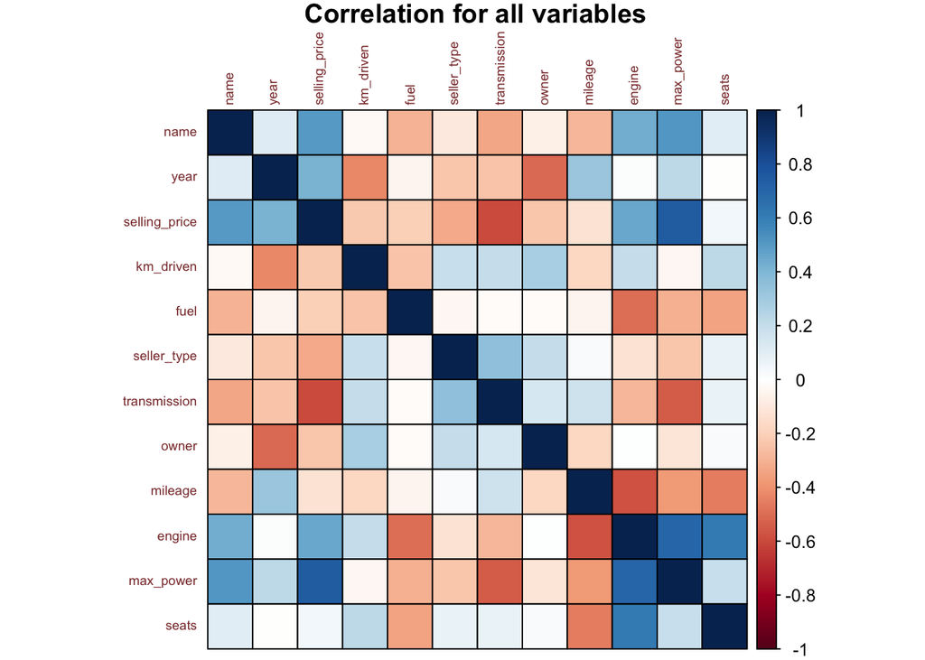

```r
library(corrplot)
corrplot(cor(vehicles), type="full",
         method ="color", title = "Correlation for all variables",
         mar=c(0,1,1,0), tl.cex= 0.6, outline= T, tl.col="indianred4")
```

```r
round(cor(vehicles),3)
```

```
##                 name   year selling_price km_driven   fuel seller_type
## name           1.000  0.114         0.503    -0.028 -0.291      -0.096
## year           0.114  1.000         0.412    -0.428 -0.046      -0.232
## selling_price  0.503  0.412         1.000    -0.222 -0.204      -0.321
## km_driven     -0.028 -0.428        -0.222     1.000 -0.247       0.193
## fuel          -0.291 -0.046        -0.204    -0.247  1.000      -0.039
## seller_type   -0.096 -0.232        -0.321     0.193 -0.039       1.000
## transmission  -0.339 -0.249        -0.590     0.201 -0.012       0.358
## owner         -0.062 -0.508        -0.233     0.287 -0.013       0.205
## mileage       -0.285  0.329        -0.126    -0.173 -0.045       0.023
## engine         0.435  0.019         0.456     0.206 -0.493      -0.120
## max_power      0.512  0.226         0.750    -0.038 -0.308      -0.239
## seats          0.109 -0.009         0.041     0.227 -0.340       0.075
##               transmission  owner mileage engine max_power  seats
## name                -0.339 -0.062  -0.285  0.435     0.512  0.109
## year                -0.249 -0.508   0.329  0.019     0.226 -0.009
## selling_price       -0.590 -0.233  -0.126  0.456     0.750  0.041
## km_driven            0.201  0.287  -0.173  0.206    -0.038  0.227
## fuel                -0.012 -0.013  -0.045 -0.493    -0.308 -0.340
## seller_type          0.358  0.205   0.023 -0.120    -0.239  0.075
## transmission         1.000  0.149   0.179 -0.283    -0.542  0.073
## owner                0.149  1.000  -0.174  0.006    -0.112  0.029
## mileage              0.179 -0.174   1.000 -0.576    -0.375 -0.452
## engine              -0.283  0.006  -0.576  1.000     0.704  0.610
## max_power           -0.542 -0.112  -0.375  0.704     1.000  0.192
## seats                0.073  0.029  -0.452  0.610     0.192  1.000
```

####Split the data

The data was split in a 80% training, 20% testing split. Stratified sampling was used as sellping price distribution was skewed.

```r
vehicles_split <- vehicles %>%
  initial_split(strata = selling_price, prop = 0.8)
vehicles_train <- training(vehicles_split)
vehicles_test <- testing(vehicles_split)
dim(vehicles_train)
```

```
## [1] 6324   12
```

```r
dim(vehicles_test)
```

```
## [1] 1583   12
```

The training data set has about 6,300 + observations and the testing data set has under 2,000 observations.

####Building the Recipe

I made a vehicles_recipe that let the model know which dataset I am using in my model and which is the predictor and which attribute I am going to predict.

I used mode as a “regression” instead of “classification” for all four of models because I changed all my data to numerical value, and regression model predicts a numeric or continuous value while classification model predicts a class label or group membership.

I made a model specification for each model that let the model knows which regression model I am going to use.

Next, I made a tibble of values from 1 to 10 for all of models beside svm model with a step function of 2 and then use tune_grid function to get means of different number. I follow this step in order to get the minimal root mean square.

```r
set.seed(4141)
vehicles_recipe <- recipe(selling_price~name+year+km_driven+seller_type+mileage+transmission+max_power+engine, data=vehicles_train) %>% step_dummy(all_nominal_predictors()) %>% step_normalize(all_predictors())

vehicles_recipe %>% prep() %>% bake(vehicles_train)
```

```
## # A tibble: 6,324 × 9
##       name   year km_driven seller_type mileage transmission max_power   engine
##      <dbl>  <dbl>     <dbl>       <dbl>   <dbl>        <dbl>     <dbl>    <dbl>
##  1 -0.526  -2.04      1.39        0.423 -0.429         0.391   -0.377   0.0738
##  2 -0.330  -1.01      1.14        0.423  0.886         0.391   -0.0429 -0.125
##  3 -0.916  -1.78      1.00        0.423 -0.825         0.391   -0.0930 -0.319
##  4 -0.916  -1.78      2.08        0.423 -0.528         0.391   -0.947  -0.786
##  5 -0.916  -3.32     -1.25        0.423 -0.825         0.391   -1.52   -1.31
##  6  0.0599 -0.246     1.96        0.423  0.142         0.391   -0.652  -0.119
##  7 -0.916  -2.29      0.609       0.423 -0.528         0.391   -0.877  -0.920
##  8 -0.916  -3.06      0.217       0.423  0.0674        0.391   -1.26   -1.31
##  9  0.450  -0.758     0.609       0.423  0.390         0.391   -0.763   0.00280
## 10 -0.916  -1.27      1.00        0.423 -0.131         0.391   -0.683  -0.786
## # … with 6,314 more rows, and 1 more variable: selling_price <int>
```

####Nearest Neighbors

```r
knn_model <-
  nearest_neighbor(
    neighbors = tune(),
    mode = "regression") %>%
  set_engine("kknn")

vehicles_vfold <- vfold_cv(vehicles_train, v=5, strata=selling_price)

knn_workflow <- workflow() %>%
  add_model(knn_model) %>%
  add_recipe(vehicles_recipe)
```

```r
set.seed(1010)
vehicles_grid <- tibble(neighbors=seq(from=1, to=10, by=2))

vehicles_results <- knn_workflow%>%
    tune_grid(resamples=vehicles_vfold, grid=vehicles_grid)
```

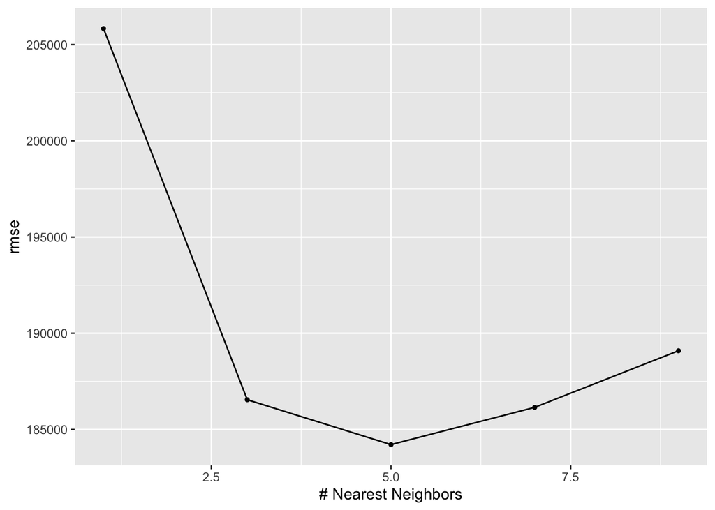

```r
autoplot(vehicles_results, metric = "rmse")
```

```r
show_best(vehicles_results, metric = "rmse")
```

```
## # A tibble: 5 × 7
##   neighbors .metric .estimator    mean     n std_err .config
##       <dbl> <chr>   <chr>        <dbl> <int>   <dbl> <chr>
## 1         5 rmse    standard   184214.     5   8748. Preprocessor1_Model3
## 2         7 rmse    standard   186151.     5   9352. Preprocessor1_Model4
## 3         3 rmse    standard   186545.     5   8168. Preprocessor1_Model2
## 4         9 rmse    standard   189092.     5   9673. Preprocessor1_Model5
## 5         1 rmse    standard   205834.     5   9249. Preprocessor1_Model1
```

I added vehicles_fit with a workflow where I add knn model, recipe and fit the model into vehicles_train. And then I use the model to predict vehicles_test and collect the metrics, then store the results into vehicles_summary.

```r
vehicles_spec <- nearest_neighbor(weight_func="rectangular", neighbors=3) %>%
    set_engine("kknn")%>%
    set_mode("regression")
vehicles_fit <- workflow() %>%
    add_recipe(vehicles_recipe) %>%
    add_model(vehicles_spec)%>%
    fit(data=vehicles_train)
vehicles_summary <- vehicles_fit %>%
    predict(vehicles_test) %>%
    bind_cols(vehicles_test) %>%
    metrics(truth=selling_price, estimate=.pred) %>%
    filter(.metric=="rmse")
vehicles_summary
```

```
## # A tibble: 1 × 3
##   .metric .estimator .estimate
##   <chr>   <chr>          <dbl>
## 1 rmse    standard     168334.
```

####SVM Model

Instead of setting up the grid from 1 to 10 just like I did for other 3 modeling, I used different method by using grid_regular, where I fit a model at every combination of parameters, and range =c(-3, -1) with level of 10 for the cost value because cost value does not naturally integer.

```r
library(kernlab)
svm_model <-
  svm_poly(
    cost = tune(),
    mode = "regression") %>%
  set_engine("kernlab")
```

```r
svm_workflow <- workflow() %>%
  add_model(svm_model) %>%
  add_recipe(vehicles_recipe)
```

```r
set.seed(1212)

vehicles_grid_svm <- grid_regular(cost(range = c(-3, -1)), levels = 10)

vehicles_results_svm <- svm_workflow %>%
    tune_grid(resamples=vehicles_vfold, grid=vehicles_grid_svm)
```

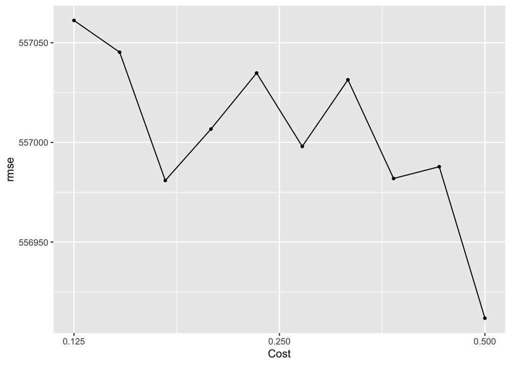

```r
autoplot(vehicles_results_svm, metric = "rmse")
```

```r
show_best(vehicles_results_svm, metric = "rmse")
```

```
## # A tibble: 5 × 7
##    cost .metric .estimator    mean     n std_err .config
##   <dbl> <chr>   <chr>        <dbl> <int>   <dbl> <chr>
## 1 0.5   rmse    standard   556912.     5  14996. Preprocessor1_Model10
## 2 0.170 rmse    standard   556981.     5  14943. Preprocessor1_Model03
## 3 0.367 rmse    standard   556982.     5  14918. Preprocessor1_Model08
## 4 0.429 rmse    standard   556988.     5  14981. Preprocessor1_Model09
## 5 0.270 rmse    standard   556998.     5  14921. Preprocessor1_Model06
```

```r
vehicles_spec_svm <- svm_poly(cost=0.2314687) %>%
    set_engine("kernlab")%>%
    set_mode("regression")
vehicles_fit_svm <- workflow() %>%
    add_recipe(vehicles_recipe) %>%
    add_model(vehicles_spec_svm)%>%
    fit(data=vehicles_train)
vehicles_summary_svm <- vehicles_fit_svm %>%
    predict(vehicles_test) %>%
    bind_cols(vehicles_test) %>%
    metrics(truth=selling_price, estimate=.pred) %>%
    filter(.metric=="rmse")
vehicles_summary_svm
```

```
## # A tibble: 1 × 3
##   .metric .estimator .estimate
##   <chr>   <chr>          <dbl>
## 1 rmse    standard     534152.
```

####Random Forest Model

```r
rf_model <-
  rand_forest(
    mtry = tune(),
    mode = "regression") %>%
  set_engine("ranger")

rf_workflow <- workflow() %>%
  add_model(rf_model) %>%
  add_recipe(vehicles_recipe)
```

```r
set.seed(1213)

vehicles_grid_rf <- tibble(mtry=seq(from=1, to=10, by=2))

vehicles_results_rf <- rf_workflow %>%
    tune_grid(resamples=vehicles_vfold, grid=vehicles_grid_rf)
```

```
## ! Fold1: preprocessor 1/1, model 5/5: 9 columns were requested but there were 8 p...
```

```
## ! Fold2: preprocessor 1/1, model 5/5: 9 columns were requested but there were 8 p...
```

```
## ! Fold3: preprocessor 1/1, model 5/5: 9 columns were requested but there were 8 p...
```

```
## ! Fold4: preprocessor 1/1, model 5/5: 9 columns were requested but there were 8 p...
```

```
## ! Fold5: preprocessor 1/1, model 5/5: 9 columns were requested but there were 8 p...
```

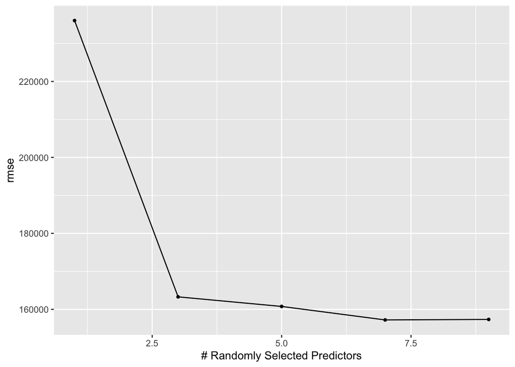

```r
autoplot(vehicles_results_rf, metric = "rmse")
```

```r
show_best(vehicles_results_rf, metric = "rmse")
```

```
## # A tibble: 5 × 7
##    mtry .metric .estimator    mean     n std_err .config
##   <dbl> <chr>   <chr>        <dbl> <int>   <dbl> <chr>
## 1     7 rmse    standard   157211.     5  13420. Preprocessor1_Model4
## 2     9 rmse    standard   157344.     5  12214. Preprocessor1_Model5
## 3     5 rmse    standard   160764.     5  15646. Preprocessor1_Model3
## 4     3 rmse    standard   163287.     5  16701. Preprocessor1_Model2
## 5     1 rmse    standard   236028.     5  17817. Preprocessor1_Model1
```

```r
vehicles_spec_rf <- rand_forest(mtry=9) %>%
    set_engine("ranger")%>%
    set_mode("regression")
vehicles_fit_rf <- workflow() %>%
    add_recipe(vehicles_recipe) %>%
    add_model(vehicles_spec_rf)%>%
    fit(data=vehicles_train)
vehicles_summary_rf <- vehicles_fit_rf %>%
    predict(vehicles_test) %>%
    bind_cols(vehicles_test) %>%
    metrics(truth=selling_price, estimate=.pred) %>%
    filter(.metric=="rmse")
vehicles_summary_rf
```

```
## # A tibble: 1 × 3
##   .metric .estimator .estimate
##   <chr>   <chr>          <dbl>
## 1 rmse    standard     125615.
```

####Boost Tree Model

```r
bt_model <-
  boost_tree(
    mtry = tune(),
    mode = "regression") %>%
  set_engine("xgboost")

bt_workflow <- workflow() %>%
  add_model(bt_model) %>%
  add_recipe(vehicles_recipe)
```

```r
set.seed(1218)

vehicles_grid_bt <- tibble(mtry=seq(from=1, to=10, by=2))

vehicles_results_bt <- bt_workflow %>%
    tune_grid(resamples=vehicles_vfold, grid=vehicles_grid_bt)
```

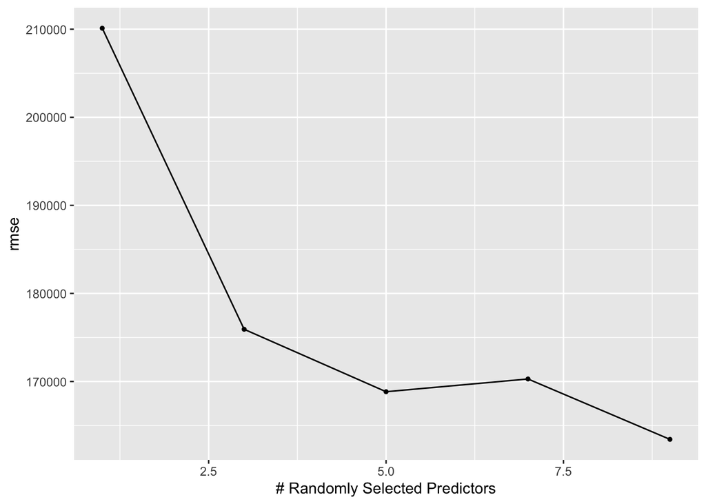

```r
autoplot(vehicles_results_bt, metric = "rmse")
```

```r
show_best(vehicles_results_bt, metric = "rmse")
```

```
## # A tibble: 5 × 7
##    mtry .metric .estimator    mean     n std_err .config
##   <dbl> <chr>   <chr>        <dbl> <int>   <dbl> <chr>
## 1     9 rmse    standard   163432.     5  14862. Preprocessor1_Model5
## 2     5 rmse    standard   168840.     5  16839. Preprocessor1_Model3
## 3     7 rmse    standard   170287.     5  17418. Preprocessor1_Model4
## 4     3 rmse    standard   175930.     5  20560. Preprocessor1_Model2
## 5     1 rmse    standard   210111.     5  23697. Preprocessor1_Model1
```

```r
vehicles_spec_bt <- boost_tree(mtry=7) %>%
    set_engine("xgboost")%>%
    set_mode("regression")
vehicles_fit_bt <- workflow() %>%
    add_recipe(vehicles_recipe) %>%
    add_model(vehicles_spec_bt)%>%
    fit(data=vehicles_train)
vehicles_summary_bt <- vehicles_fit_bt %>%
    predict(vehicles_test) %>%
    bind_cols(vehicles_test) %>%
    metrics(truth=selling_price, estimate=.pred) %>%
    filter(.metric=="rmse")
vehicles_summary_bt
```

```
## # A tibble: 1 × 3
##   .metric .estimator .estimate
##   <chr>   <chr>          <dbl>
## 1 rmse    standard     129882.
```

####CONCLUSION

```r
Model <- c('K-nearest neighbors', 'Support Vector Machine', 'Random Forest', 'Boost Tree')
vehicles_summary <- select_if(vehicles_summary, is.numeric)
vehicles_summary_svm <- select_if(vehicles_summary_svm, is.numeric)
vehicles_summary_rf <- select_if(vehicles_summary_rf, is.numeric)
vehicles_summary_bt <- select_if(vehicles_summary_bt, is.numeric)
RMSE <- c(vehicles_summary, vehicles_summary_svm, vehicles_summary_rf, vehicles_summary_bt)
RMSE_value <- as.numeric(RMSE)

Table <- data.frame(Model,RMSE_value)
Table
```

```
##                    Model RMSE_value
## 1    K-nearest neighbors   168333.7
## 2 Support Vector Machine   534152.2
## 3          Random Forest   125614.8
## 4             Boost Tree   129881.6
```

After thorough analysis of the dataset, I was successful in making reasonable conclusions regarding the sale prices in used cars and automobile industry generally.

Root-Mean-Square-Error or RMSE measures how much error there is between two data sets. In the other words, It compares a predicted value and an observed or known value. Which means, when we have the smaller an RMSE value, the closer predicted and observed values are.

By using different machine learning models, I aimed to get better result that has lower error. My purpose was to predict the price of used cars having 7907 data entries after get rid of NA values.

I used four different models, in the order of Knn model, SVM model, Random Forest model, Boost Tree model. Before I set up the model, I expected Boost-Tree model will bring the lowest RMSE value because Boost-Trees have a lot of model capacity, so it can model very complex decision boundries and relationships compare to Random Forest model. However, I realize that with all models with high capacity, it can lead to overfitting very quickly just like I learned from lab 7.

From the above table, It can be concluded that Random Forest is the best model for the prediction for used car prices. Random Forest as a regression model gave the lowest RMSE values.

And here is graph describing the performance of your best-fitting model on testing data

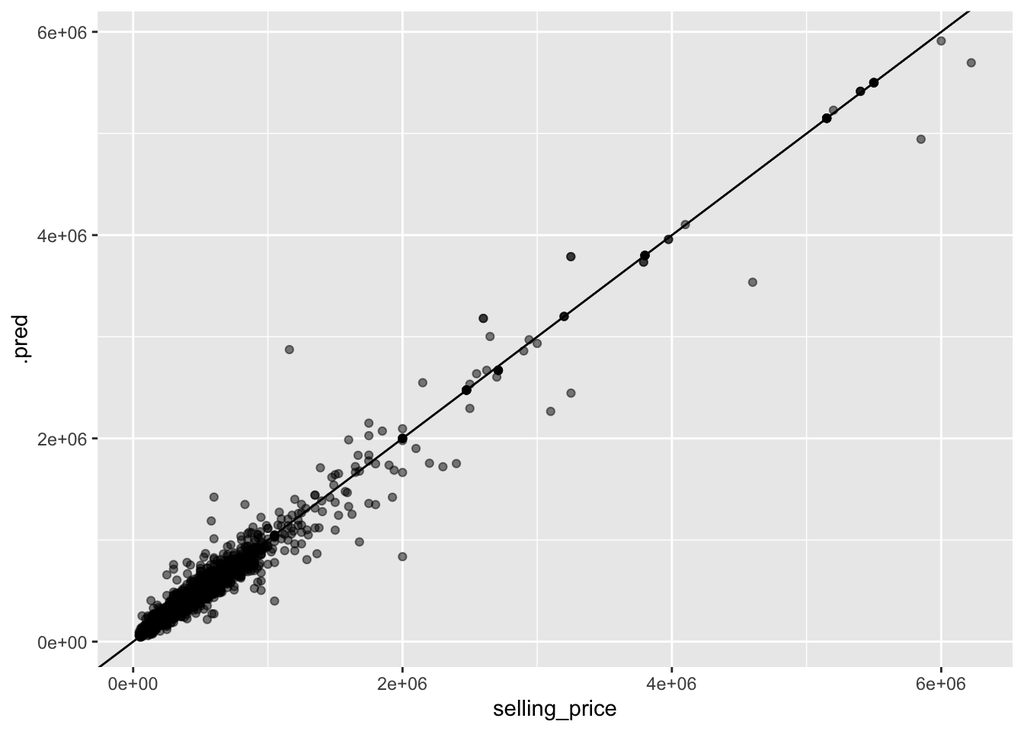

```r
augment(vehicles_fit_rf, new_data = vehicles_test) %>%
  ggplot(aes(selling_price, .pred)) +
  geom_abline() +
  geom_point(alpha = 0.5)
```